# HQNN EstimatorQNN

### 1. **IMPORTS**

```python
import numpy as np
import matplotlib.pyplot as plt

import torch
from torch import cat
import torch.nn as nn
import torch.optim as optim
from torchvision import datasets, transforms
from torch.utils.data import Dataset, DataLoader, random_split
from torch.nn import (
    Module,
    Conv2d,
    Linear,
    Dropout2d,
    NLLLoss,
    MaxPool2d,
    Flatten,
    Sequential,
    ReLU,
    Identity
)
import torch.nn.functional as F

from sklearn.metrics import classification_report, confusion_matrix

from qiskit.primitives import StatevectorEstimator as Estimator
from qiskit.circuit.library import (
    zz_feature_map,
    pauli_feature_map,
    real_amplitudes,
    efficient_su2,
)
from qiskit_machine_learning.neural_networks import EstimatorQNN
from qiskit import QuantumCircuit
from qiskit_machine_learning.connectors import TorchConnector
```

### 2. **REPRODUCIBILIDAD (SEED)**

```python
import random
import os
import numpy as np
import torch

SEED = 42

# Python
random.seed(SEED)

# NumPy
np.random.seed(SEED)

# PyTorch CPU
torch.manual_seed(SEED)

# PyTorch CUDA
if torch.cuda.is_available():
    torch.cuda.manual_seed(SEED)
    torch.cuda.manual_seed_all(SEED)

# Reproducibilidad CUDA/cuDNN
torch.backends.cudnn.deterministic = True
torch.backends.cudnn.benchmark = False

# Opcional: operaciones deterministas estrictas
# torch.use_deterministic_algorithms(True)

print(f"Seed fijada: {SEED}")
```

```python
transform = transforms.Compose([transforms.ToTensor()])
# transform = transforms.Compose([
#     transforms.Resize((32, 32)),
#     transforms.ToTensor()
# ])

X_train = datasets.MNIST(root="./data", train=True, download=True, transform=transform)
X_test = datasets.MNIST(root="./data", train=False, download=True, transform=transform)
```

```python
n_samples_train = 400
n_samples_test = 100

X_train.data = X_train.data[:n_samples_train]
X_train.targets = X_train.targets[:n_samples_train]

X_test.data = X_test.data[:n_samples_test]
X_test.targets = X_test.targets[:n_samples_test]
```

```python
train_size = 300
val_size = 100

generator = torch.Generator().manual_seed(SEED)

train_subset, val_subset = random_split(X_train, [train_size, val_size], generator=generator)
```

```python
def gaussian_noise(img, sigma=0.25): # antes 0.1
    noise = torch.randn_like(img) * sigma
    return torch.clamp(img + noise, 0, 1)

def salt_pepper(img, prob=0.15): # antes 0.05
    noisy = img.clone()

    mask = torch.rand_like(img)

    noisy[mask < prob/2] = 0
    noisy[mask > 1 - prob/2] = 1

    return noisy

def speckle(img, sigma=0.35): # antes 0.2
    noise = torch.randn_like(img) * sigma
    return torch.clamp(img + img * noise, 0, 1)


def apply_mixed_noise(img):
    r = np.random.randint(3)

    # gaussian + speckle
    if r == 0:
        img = gaussian_noise(img)
        img = speckle(img)
        label = 0

    # gaussian + salt & pepper
    elif r == 1:
        img = gaussian_noise(img)
        img = salt_pepper(img)
        label = 1

    # salt & pepper + speckle
    else:
        img = salt_pepper(img)
        img = speckle(img)
        label = 2

    return img, label
```

```python
class NoisyMNISTDataset(Dataset):
    def __init__(self, mnist_dataset):
        self.mnist = mnist_dataset

        # Aquí preprocesamos todas las imágenes y guardamos el ruido y las etiquetas
        self.noisy_images = []
        self.labels = []

        for img, _ in self.mnist:
            noisy_img, label = apply_mixed_noise(img)
            self.noisy_images.append(noisy_img)
            self.labels.append(label)

        # Comprobación de consistencia
        if len(self.noisy_images) != len(self.labels):
            raise Exception("Incompatible arrays")


    def __len__(self):
        return len(self.mnist)

    def __getitem__(self, idx):
        return self.noisy_images[idx], self.labels[idx]


train_dataset = NoisyMNISTDataset(train_subset)
val_dataset = NoisyMNISTDataset(val_subset)
test_dataset = NoisyMNISTDataset(X_test)
```

```python
train_generator = torch.Generator()
train_generator.manual_seed(SEED)

train_loader = DataLoader(train_dataset, batch_size=32, shuffle=True, generator=train_generator)
val_loader = DataLoader(val_dataset, batch_size=32, shuffle=False)
test_loader = DataLoader(test_dataset, batch_size=32, shuffle=False)

images, labels = next(iter(train_loader))

print(images.shape)  # [32, 1, 28, 28]
print(labels.shape)
```

```
torch.Size([32, 1, 28, 28])
torch.Size([32])
```

```
No gradient function provided, creating a gradient function. If your Estimator requires transpilation, please provide a pass manager.
```

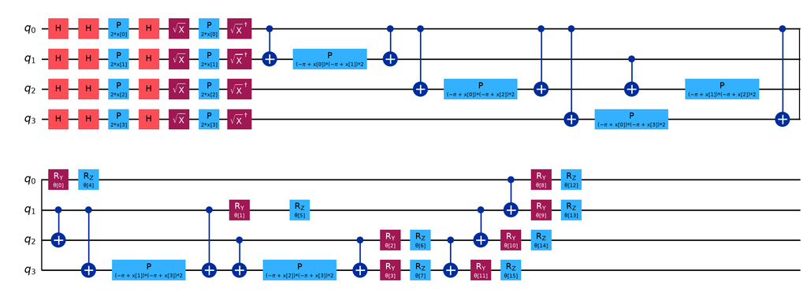

```python
from qiskit.quantum_info import Pauli, SparsePauliOp
# from qiskit.circuit.library import ZZFeatureMap


    # ExperimentConfig(
    #     name="A4",
    #     n_qubits=4,
    #     feature_map="pauli",
    #     ansatz="efficient_su2",
    #     observable_mode="z_individual",
    # ),

observables = [
    SparsePauliOp.from_list([("ZIII", 1.0)]),
    SparsePauliOp.from_list([("IZII", 1.0)]),
    SparsePauliOp.from_list([("IIZI", 1.0)]),
    SparsePauliOp.from_list([("IIIZ", 1.0)]),
]


# observables = [
#     SparsePauliOp.from_list([("ZIII", 1.0), ("IZII", 1.0)]),
#     SparsePauliOp.from_list([("ZZII", 1.0)]),
#     SparsePauliOp.from_list([("IIZZ", 1.0)])
# ] # mejor resultado

estimator = Estimator()
def create_qnn():
    feature_map = pauli_feature_map(4, paulis=["X", "Y", "ZZ"], reps=1, entanglement="full")
    # feature_map = zz_feature_map(4, entanglement="full", reps=1)
    ansatz = efficient_su2(4, entanglement="reverse_linear", reps=1)
    # ansatz = real_amplitudes(4, entanglement="reverse_linear", reps=1)
    qc = QuantumCircuit(4)
    qc.compose(feature_map, inplace=True)
    qc.compose(ansatz, inplace=True)


    # REMEMBER TO SET input_gradients=True FOR ENABLING HYBRID GRADIENT BACKPROP
    qnn = EstimatorQNN(
        circuit=qc,
        input_params=feature_map.parameters,
        weight_params=ansatz.parameters,
        input_gradients=True,
        estimator=estimator,
        observables=observables
    )
    return qnn


qnn = create_qnn()

qnn.circuit.draw("mpl")
```

```python
class Net(nn.Module):
    def __init__(self, qnn):
        super().__init__()
        # 2 capas convolucionales
        self.conv1 = nn.Conv2d(1, 16, kernel_size=5, padding=2)
        self.conv2 = nn.Conv2d(16, 32, kernel_size=5, padding=2)
        self.pool = nn.MaxPool2d(2)  # reduce dimensiones a la mitad

        # fully connected
        self.fc1 = nn.Linear(32*7*7, 128)  # flatten 32×7×7=1568
        self.fc2 = nn.Linear(128, 4)      # vector final 4D para QNN

        # QNN
        self.qnn = TorchConnector(qnn)
        # 3Capa lineal final (mapear expectation values → logits 3 clases)
        #self.fc_final = nn.Identity()
        self.fc_final = nn.Linear(len(qnn.observables), 3)
    def forward(self, x):
        # Extracción de features clásicas
        x = F.relu(self.conv1(x))
        x = self.pool(x)
        x = F.relu(self.conv2(x))
        x = self.pool(x)

        # Flatten y proyección fully connected
        x = x.view(x.shape[0], -1)
        x = F.relu(self.fc1(x))
        x = torch.tanh(self.fc2(x)) * np.pi

        # Forward QNN
        x = self.qnn(x)
        # Capa lineal final → logits:
        x = self.fc_final(x)
        return x

hqnn = Net(qnn)
```

```python
import torch
print(torch.cuda.is_available())

device = torch.device("cuda" if torch.cuda.is_available() else "cpu")
hqnn.to(device)
```

```
True
```

```
Net(
  (conv1): Conv2d(1, 16, kernel_size=(5, 5), stride=(1, 1), padding=(2, 2))
  (conv2): Conv2d(16, 32, kernel_size=(5, 5), stride=(1, 1), padding=(2, 2))
  (pool): MaxPool2d(kernel_size=2, stride=2, padding=0, dilation=1, ceil_mode=False)
  (fc1): Linear(in_features=1568, out_features=128, bias=True)
  (fc2): Linear(in_features=128, out_features=4, bias=True)
  (qnn): TorchConnector()
  (fc_final): Linear(in_features=4, out_features=3, bias=True)
)
```

```python
device
```

```
device(type='cuda')
```

```python
# Separar parámetros correctamente
optimizer = optim.Adam(hqnn.parameters(), lr=0.001)
criterion = nn.CrossEntropyLoss()
# CrossEntropyLoss: combina LogSoftmax + NLLLoss, por lo que espera logits sin softmax
# logits = raw outputs del modelo, sin softmax
# LogSoftmax: convierte logits en probabilidades logarítmicas
# NLLLoss: calcula la pérdida negativa logarítmica entre las probabilidades logarítmicas y las etiquetas verdaderas

epochs = 10
# Lista para guardar pérdidas de entrenamiento y validación
train_loss_list = []
val_loss_list = []

# Lista para guardar accuracies
train_acc_list = []
val_acc_list = []

for epoch in range(epochs):
    ##############################
    # Entrenamiento
    ##############################
    hqnn.train()  # modo entrenamiento
    total_loss = 0
    correct = 0
    total = 0

    for data, target in train_loader:
        data, target = data.to(device), target.to(device)

        optimizer.zero_grad()          # reset gradientes
        output = hqnn(data)            # forward pass
        loss = criterion(output, target)
        loss.backward()                # backprop
        optimizer.step()               # update pesos

        total_loss += loss.item() * data.size(0)  # sumar pérdida
        _, predicted = torch.max(output, 1)
        correct += (predicted == target).sum().item()
        total += target.size(0)

    avg_train_loss = total_loss / total
    train_acc = correct / total
    train_loss_list.append(avg_train_loss)
    train_acc_list.append(train_acc)


    # Validación
    hqnn.eval()  # modo evaluación
    val_loss = 0
    correct = 0
    total = 0

    with torch.no_grad():  # no calculamos gradientes
        for data, target in val_loader:
            data, target = data.to(device), target.to(device)
            output = hqnn(data)
            loss = criterion(output, target)

            val_loss += loss.item() * data.size(0)
            _, predicted = torch.max(output, 1)
            correct += (predicted == target).sum().item()
            total += target.size(0)

    avg_val_loss = val_loss / total
    val_acc = correct / total
    val_loss_list.append(avg_val_loss)
    val_acc_list.append(val_acc)

    # Mostrar métricas
    print(f"Epoch {epoch+1}/{epochs} | "
          f"Train Loss: {avg_train_loss:.4f} | Train Acc: {train_acc:.4f} | "
          f"Val Loss: {avg_val_loss:.4f} | Val Acc: {val_acc:.4f}")
```

[output not shown]

```python
# ----------------------------
# Evaluación en test
# ----------------------------
hqnn.eval()  # modo evaluación
all_preds = []
all_targets = []

with torch.no_grad():
    for data, target in test_loader:
        data, target = data.to(device), target.to(device)
        output = hqnn(data)
        _, preds = torch.max(output, 1)
        all_preds.append(preds.cpu())
        all_targets.append(target.cpu())

# Concatenamos todos los batches
all_preds = torch.cat(all_preds)
all_targets = torch.cat(all_targets)

# Confusion matrix
cm = confusion_matrix(all_targets, all_preds)
print("Confusion Matrix:")
print(cm)

# Classification report
report = classification_report(all_targets, all_preds, target_names=["gaussian+speckle", "gaussian+saltpepper", "saltpepper+speckle"])
print("\nClassification Report:")
print(report)

# Accuracy total
accuracy = (all_preds == all_targets).float().mean().item()
print(f"\nTest Accuracy: {accuracy:.4f}")
```

```
Confusion Matrix:
[[33  0  0]
 [ 0 20  8]
 [ 0  2 37]]

Classification Report:
                     precision    recall  f1-score   support

   gaussian+speckle       1.00      1.00      1.00        33
gaussian+saltpepper       0.91      0.71      0.80        28
 saltpepper+speckle       0.82      0.95      0.88        39

           accuracy                           0.90       100
          macro avg       0.91      0.89      0.89       100
       weighted avg       0.91      0.90      0.90       100


Test Accuracy: 0.9000
```

```python
# observables = [
#     SparsePauliOp.from_list([("ZIII", 1.0), ("IZII", 1.0)]),
#     SparsePauliOp.from_list([("ZZII", 1.0)]),
#     SparsePauliOp.from_list([("IIZZ", 1.0)])
# ] # mejor resultado

    # feature_map = zz_feature_map(4, entanglement="full", reps=1)
    # ansatz = real_amplitudes(4, entanglement="reverse_linear", reps=1)

        # self.fc_final = nn.Identity()
```

RESULTS

Epoch 1/10 | Train Loss: 1.0814 | Train Acc: 0.4233 | Val Loss: 1.0594 | Val Acc: 0.3600 Epoch 2/10 | Train Loss: 0.9864 | Train Acc: 0.5833 | Val Loss: 0.9021 | Val Acc: 0.7000 Epoch 3/10 | Train Loss: 0.8953 | Train Acc: 0.7433 | Val Loss: 0.8562 | Val Acc: 0.7000 Epoch 4/10 | Train Loss: 0.8569 | Train Acc: 0.8367 | Val Loss: 0.8382 | Val Acc: 0.9200 Epoch 5/10 | Train Loss: 0.8292 | Train Acc: 0.9567 | Val Loss: 0.8363 | Val Acc: 0.8400 Epoch 6/10 | Train Loss: 0.8159 | Train Acc: 0.9567 | Val Loss: 0.8442 | Val Acc: 0.8700 Epoch 7/10 | Train Loss: 0.8124 | Train Acc: 0.9933 | Val Loss: 0.8033 | Val Acc: 0.9800 Epoch 8/10 | Train Loss: 0.8123 | Train Acc: 0.9567 | Val Loss: 0.8013 | Val Acc: 0.9800 Epoch 9/10 | Train Loss: 0.7809 | Train Acc: 0.9900 | Val Loss: 0.7844 | Val Acc: 0.9100 Epoch 10/10 | Train Loss: 0.7555 | Train Acc: 0.9967 | Val Loss: 0.7648 | Val Acc: 0.9500

[output not shown]

### **GUARDAR EN HTML**

```python
import sys
import subprocess
from pathlib import Path

notebook = Path("Hybrid CNN-QNN.ipynb").resolve()
output_dir = notebook.parent

result = subprocess.run(
    [
        sys.executable,
        "-m",
        "nbconvert",
        "--to", "html",
        str(notebook),
        "--output-dir", str(output_dir),
    ],
    capture_output=True,
    text=True
)

print("RETURN CODE:", result.returncode)
print("\n--- STDOUT ---")
print(result.stdout)
print("\n--- STDERR ---")
print(result.stderr)

if result.returncode == 0:
    html_file = output_dir / "Hybrid CNN-QNN.html"
    print(f"\n✅ HTML generado correctamente:")
    print(html_file)
```